# R Notebook on Discriminant Analysis

Discriminant analysis is used to predict the probability of belonging to a given class (or category) based on one or multiple predictor variables. It works with continuous and/or categorical predictor variables.

- Linear discriminant analysis (LDA): Uses linear combinations of predictors to predict the class of a given observation. Assumes that the predictor variables are normally distributed and the classes have identical variances (for univariate analysis) or identical covariance matrices (for multivariate analysis).
- Quadratic discriminant analysis (QDA): More flexible than LDA. Here, there is no assumption that the covariance matrix of classes is the same.
- Mixture discriminant analysis (MDA): Each class is assumed to be a Gaussian mixture of subclasses.
- Flexible discriminant analysis (FDA): Non-linear combinations of predictors is used such as splines.
- Regularized discriminant analysis (RDA): Regularization (or shrinkage) improves the estimate of the covariance matrices in situations where the number of predictors is larger than the number of samples in the training data. This leads to an improvement of the discriminant analysis.

# Loading required R packages

**tidyverse** for easy data manipulation and visualization **caret** for easy machine learning workflow

```r
library(tidyverse)
library(caret)
theme_set(theme_classic())
```

# Preparing the data

Discriminant analysis can be affected by the scale/unit in which predictor variables are measured. It’s generally recommended to standardize/normalize continuous predictor before the analysis.

1. Split the data into training and test set:

```r
# Load the data
data("iris")
# Split the data into training (80%) and test set (20%)
set.seed(123)
training.samples <- iris$Species %>%
  createDataPartition(p = 0.8, list = FALSE)
train.data <- iris[training.samples, ]
test.data <- iris[-training.samples, ]
```

2. Normalize the data. Categorical variables are automatically ignored.

```r
# Estimate preprocessing parameters
preproc.param <- train.data %>%
  preProcess(method = c("center", "scale"))
# Transform the data using the estimated parameters
train.transformed <- preproc.param %>% predict(train.data)
test.transformed <- preproc.param %>% predict(test.data)
train.transformed
```

|  | Sepal.Length | Sepal.Width | Petal.Length | Petal.Width | Species |
| --- | --- | --- | --- | --- | --- |
| 3 | -1.33582146 | 0.3647704 | -1.38220954 | -1.29654087 | setosa |
| 4 | -1.45172787 | 0.1202316 | -1.27044058 | -1.29654087 | setosa |
| 5 | -0.98810221 | 1.3429258 | -1.32632506 | -1.29654087 | setosa |
| 7 | -1.45172787 | 0.8538481 | -1.32632506 | -1.16848745 | setosa |
| 8 | -0.98810221 | 0.8538481 | -1.27044058 | -1.29654087 | setosa |
| 9 | -1.68354071 | -0.3688461 | -1.32632506 | -1.29654087 | setosa |
| 10 | -1.10400862 | 0.1202316 | -1.27044058 | -1.42459429 | setosa |
| 11 | -0.52447654 | 1.5874647 | -1.27044058 | -1.29654087 | setosa |
| 12 | -1.21991504 | 0.8538481 | -1.21455609 | -1.29654087 | setosa |
| 13 | -1.21991504 | -0.1243072 | -1.32632506 | -1.42459429 | setosa |

[output cut: 110 more lines]

# Linear discriminant analysis - LDA

The LDA algorithm starts by finding directions that maximize the separation between classes, then use these directions to predict the class of individuals. These directions, called linear discriminants, are a linear combinations of predictor variables.

LDA assumes that predictors are normally distributed (Gaussian distribution) and that the different classes have class-specific means and equal variance/covariance.

Before performing LDA, consider:

- Inspecting the univariate distributions of each variable and make sure that they are normally distribute. If not, you can transform them using log and root for exponential distributions and Box-Cox for skewed distributions.
- Removing outliers from your data and standardize the variables to make their scale comparable. The linear discriminant analysis can be easily computed using the function **lda()** [MASS package].

```r
library(MASS)
# Fit the model
model <- lda(Species~., data = train.transformed)

model
```

```
## Call:
## lda(Species ~ ., data = train.transformed)
##
## Prior probabilities of groups:
##     setosa versicolor  virginica
##  0.3333333  0.3333333  0.3333333
##
## Group means:
##            Sepal.Length Sepal.Width Petal.Length Petal.Width
## setosa       -1.0112835  0.78048647   -1.2900001  -1.2453195
## versicolor    0.1014181 -0.68674658    0.2566029   0.1472614
## virginica     0.9098654 -0.09373989    1.0333972   1.0980581
##
## Coefficients of linear discriminants:
##                     LD1         LD2
## Sepal.Length  0.6794973  0.04463786
## Sepal.Width   0.6565085 -1.00330120
## Petal.Length -3.8365047  1.44176147
## Petal.Width  -2.2722313 -1.96516251
##
## Proportion of trace:
##    LD1    LD2
## 0.9902 0.0098
```

LDA determines group means and computes, for each individual, the probability of belonging to the different groups. The individual is then affected to the group with the highest probability score.

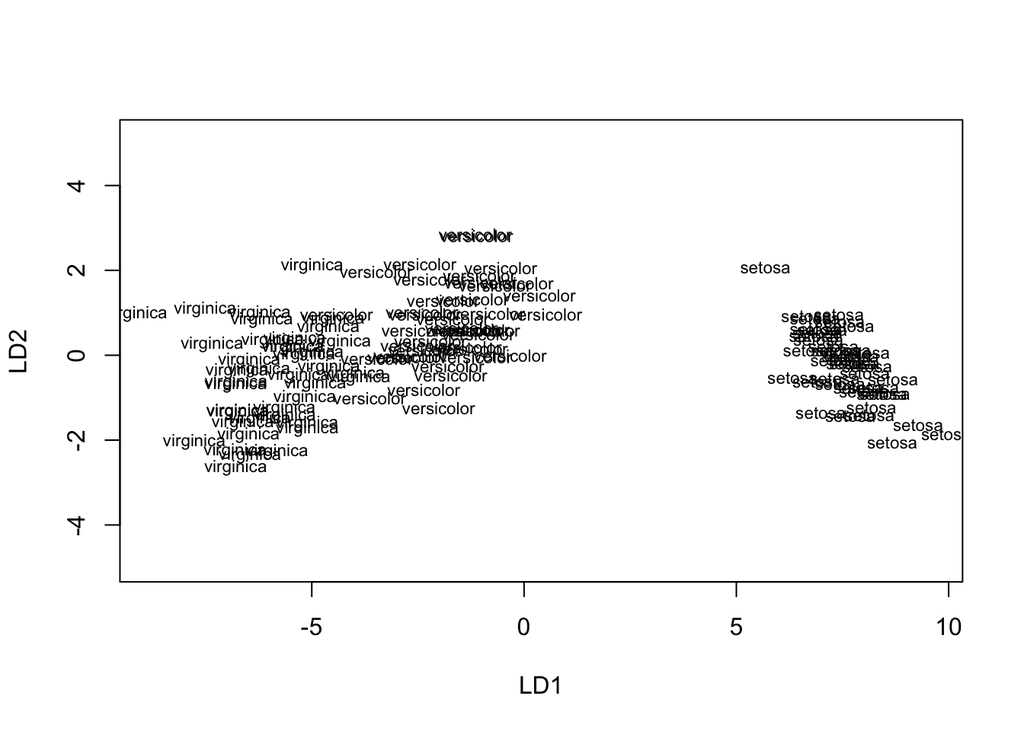

```r
# Using the function plot() produces plots of the linear discriminants, obtained by computing LD1 and LD2 for each of the training observations.
plot(model)
```

```r
# Make predictions
predictions <- model %>% predict(test.transformed)
# Model accuracy
mean(predictions$class==test.transformed$Species)
```

```
## [1] 0.9666667
```

```r
names(predictions)
```

```
## [1] "class"     "posterior" "x"
```

The **predict()** function returns the following elements:

- class: predicted classes of observations.
- posterior: is a matrix whose columns are the groups, rows are the individuals and values are the posterior probability that the corresponding observation belongs to the groups.
- x: contains the linear discriminants, described above

```r
# Inspect the results:
# Predicted classes
head(predictions$class, 6)
```

```
## [1] setosa setosa setosa setosa setosa setosa
## Levels: setosa versicolor virginica
```

```r
# Predicted probabilities of class memebership.
head(predictions$posterior, 6)
```

```
##    setosa   versicolor    virginica
## 1       1 3.978425e-22 1.319337e-43
## 2       1 1.038098e-17 3.967605e-38
## 6       1 2.882148e-21 2.041612e-41
## 16      1 8.381782e-28 7.486309e-50
## 23      1 6.531615e-25 3.414098e-47
## 34      1 1.089899e-28 7.865614e-52
```

```r
# Linear discriminants
head(predictions$x, 3)
```

```
##        LD1        LD2
## 1 8.162939 -0.5052768
## 2 7.202713  0.7111062
## 6 7.816243 -1.7327151
```

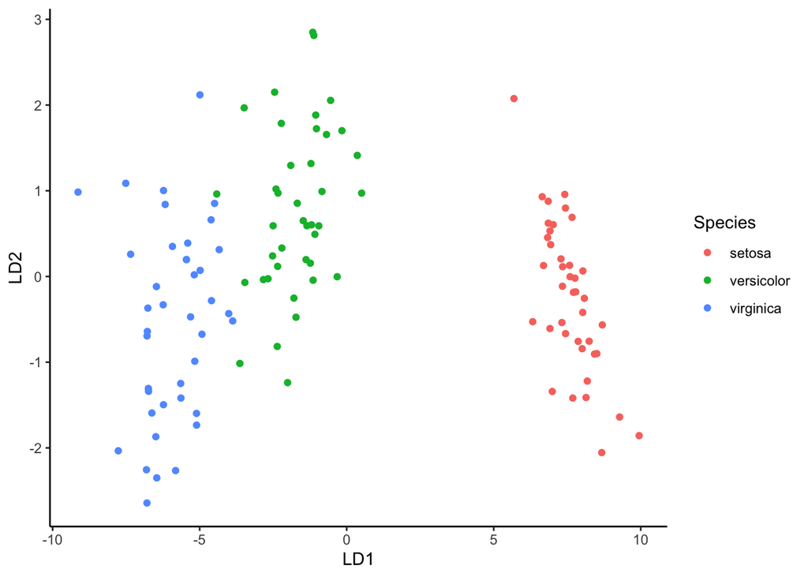

```r
# create the LDA plot using ggplot2 as follow:
lda.data <- cbind(train.transformed, predict(model)$x)
ggplot(lda.data, aes(LD1, LD2)) +
  geom_point(aes(color = Species))
```

```r
# compute the model accuracy as follow:
mean(predictions$class==test.transformed$Species)
```

```
## [1] 0.9666667
```

```r
# by default, the probability cutoff used to decide group-membership is 0.5 (random guessing). For example, the number of observations in the setosa group can be re-calculated using:
sum(predictions$posterior[ ,1] >=.5)
```

```
## [1] 10
```

In some situations, you might want to increase the precision of the model. In this case you can fine-tune the model by adjusting the posterior probability cutoff. For example, you can increase or lower the cutoff.

# Quadratic discriminant analysis - QDA

QDA is little bit more flexible than LDA, in the sense that it does not assumes the equality of variance/covariance. In other words, for QDA the covariance matrix can be different for each class.

LDA tends to be a better than QDA when you have a small training set.

In contrast, QDA is recommended if the training set is very large, so that the variance of the classifier is not a major issue, or if the assumption of a common covariance matrix for the K classes is clearly untenable

QDA can be computed using the R function **qda()** [MASS package]

```r
library(MASS)
# Fit the model
model <- qda(Species~., data = train.transformed)
model
```

```
## Call:
## qda(Species ~ ., data = train.transformed)
##
## Prior probabilities of groups:
##     setosa versicolor  virginica
##  0.3333333  0.3333333  0.3333333
##
## Group means:
##            Sepal.Length Sepal.Width Petal.Length Petal.Width
## setosa       -1.0112835  0.78048647   -1.2900001  -1.2453195
## versicolor    0.1014181 -0.68674658    0.2566029   0.1472614
## virginica     0.9098654 -0.09373989    1.0333972   1.0980581
```

```r
# Make predictions
predictions <- model %>% predict(test.transformed)
# Model accuracy
mean(predictions$class == test.transformed$Species)
```

```
## [1] 0.9666667
```

```r
names(predictions)
```

```
## [1] "class"     "posterior"
```

# Mixture discriminant analysis - MDA

The LDA classifier assumes that each class comes from a single normal (or Gaussian) distribution. This is too restrictive.

For MDA, there are classes, and each class is assumed to be a Gaussian mixture of subclasses, where each data point has a probability of belonging to each class. Equality of covariance matrix, among classes, is still assumed.

```r
library(mda)
# Fit the model
model <- mda(Species~., data = train.transformed)
model
```

```
## Call:
## mda(formula = Species ~ ., data = train.transformed)
##
## Dimension: 4
##
## Percent Between-Group Variance Explained:
##     v1     v2     v3     v4
##  95.12  97.74  99.75 100.00
##
## Degrees of Freedom (per dimension): 5
##
## Training Misclassification Error: 0.01667 ( N = 120 )
##
## Deviance: 9.635
```

```r
# Make predictions
predicted.classes <- model %>% predict(test.transformed)
# Model accuracy
mean(predicted.classes == test.transformed$Species)
```

```
## [1] 0.9666667
```

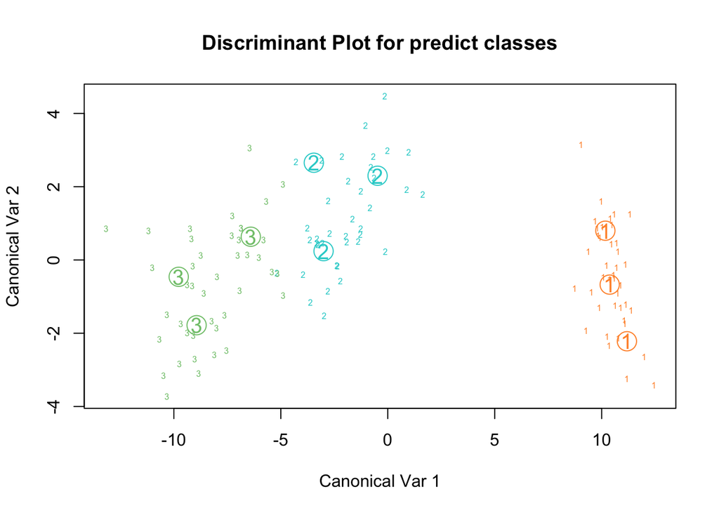

```r
plot(model)
```

# Flexible discriminant analysis - FDA

FDA is a flexible extension of LDA that uses non-linear combinations of predictors such as splines. FDA is useful to model multivariate non-normality or non-linear relationships among variables within each group, allowing for a more accurate classification.

```r
library(mda)
# Fit the model
model <- fda(Species~., data = train.transformed)
# Make predictions
predicted.classes <- model %>% predict(test.transformed)
# Model accuracy
mean(predicted.classes == test.transformed$Species)
```

```
## [1] 0.9666667
```

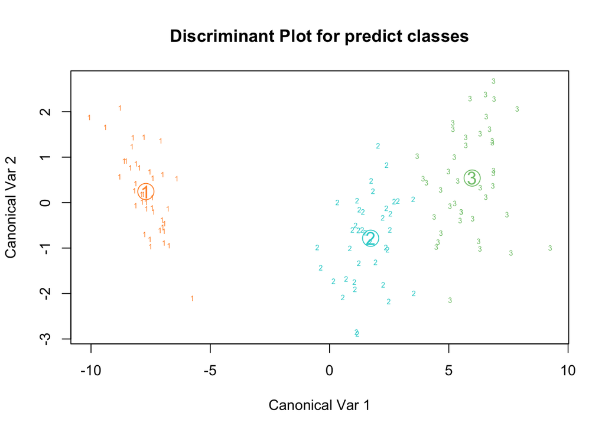

```r
plot(model)
```

# Regularized discriminant analysis

RDA builds a classification rule by regularizing the group covariance matrices allowing a more robust model against multicollinearity in the data. This might be very useful for a large multivariate data set containing highly correlated predictors.

Regularized discriminant analysis is a kind of a trade-off between LDA and QDA. Recall that, in LDA we assume equality of covariance matrix for all of the classes. QDA assumes different covariance matrices for all the classes. Regularized discriminant analysis is an intermediate between LDA and QDA.

RDA shrinks the separate covariances of QDA toward a common covariance as in LDA. This improves the estimate of the covariance matrices in situations where the number of predictors is larger than the number of samples in the training data, potentially leading to an improvement of the model accuracy.

```r
library(klaR)
# Fit the model
model <- rda(Species~., data = train.transformed)
# Make predictions
predictions <- model %>% predict(test.transformed)
# Model accuracy
mean(predictions$class == test.transformed$Species)
```

```
## [1] 0.9333333
```

# Penalized discriminant analysis

```r
library(penalizedLDA)
set.seed(1)
n <- 20
p <- 100
x <- matrix(rnorm(n*p), ncol=p)
y <- c(rep(1,5),rep(2,5),rep(3,10))
x[y==1,1:10] <- x[y==1,1:10] + 2
x[y==2,11:20] <- x[y==2,11:20] - 2
out <- PenalizedLDA(x,y,lambda=.14,K=2)
print(out)
```

```
## Number of discriminant vectors:  2
## Number of nonzero features in discriminant vector  1 : 29
## Number of nonzero features in discriminant vector  2 : 35
## Total number of nonzero features:  45
##
## Details:
## Type:  standard
## Lambda:  0.14
```

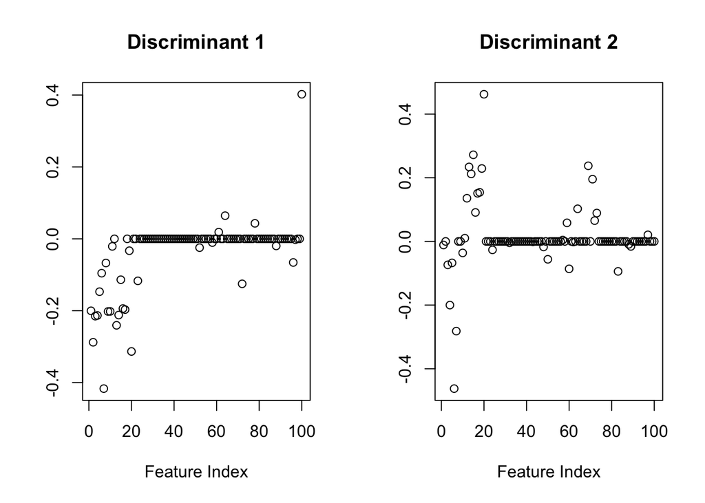

```r
plot(out)
```

```r
# tuning parameter selected by cross-validation
# Generate data #
set.seed(1)
n <- 20 # number of training obs
m <- 40 # number of test obs
p <- 100 # number of features
x <- matrix(rnorm(n*p), ncol=p)
xte <- matrix(rnorm(m*p), ncol=p)
y <- c(rep(1,5),rep(2,5),rep(3,6), rep(4,4))
yte <- rep(1:4, each=10)
x[y==1,1:10] <- x[y==1,1:10] + 2
x[y==2,11:20] <- x[y==2,11:20] - 2
x[y==3,21:30] <- x[y==3,21:30] - 2.5
xte[yte==1,1:10] <- xte[yte==1,1:10] + 2
xte[yte==2,11:20] <- xte[yte==2,11:20] - 2
xte[yte==3,21:30] <- xte[yte==3,21:30] - 2.5
# Perform cross-validation #
# Use type="ordered" -- that is, we are assuming that the features have
# some sort of spatial structure
cv.out <-PenalizedLDA.cv(x,y,type="ordered",lambdas=c(1e-4,1e-3,1e-2,.1,1,10),lambda2=.3)
```

```
## Fold  1
## 123456Fold  2
## 123456Fold  3
## 123456Fold  4
## 123456Fold  5
## 123456Fold  6
## 123456Best K is  2
```

```r
print(cv.out)
```

```
## Cross-validation Results:
## Values of Lambda considered:  0 0.001 0.01 0.1 1 10
## Values of K considered:  1 2 3
## Matrix of Cross-Validation Errors:
## K=1  K=2 K=3
## Lambda=0 0.5 0   0
## Lambda=0.001 0.5 0   0
## Lambda=0.01  0.5 0   0
## Lambda=0.1   1   0   0
## Lambda=1 2.333   2.333   2.333
## Lambda=10    2.333   2.333   2.333
## Matrix of Number of Nonzero Features:
## K=1  K=2 K=3
## Lambda=0 100 100 100
## Lambda=0.001 98  100 100
## Lambda=0.01  77.833  98  100
## Lambda=0.1   20.333  30.833  30.833
## Lambda=1 0   0   0
## Lambda=10    0   0   0
## Best Lambda:  0.1  Best K :  2
```

```r
plot(cv.out)
# Perform penalized LDA #
out <- PenalizedLDA(x,y,xte=xte,type="ordered", lambda=cv.out$bestlambda,
K=cv.out$bestK, lambda2=.3)
print(out)
```

```
## Number of discriminant vectors:  2
## Number of nonzero features in discriminant vector  1 : 20
## Number of nonzero features in discriminant vector  2 : 21
## Total number of nonzero features:  31
##
## Details:
## Type:  ordered
## Lambda:  0.1
## Lambda2:  0.3
```

[figure not shown]

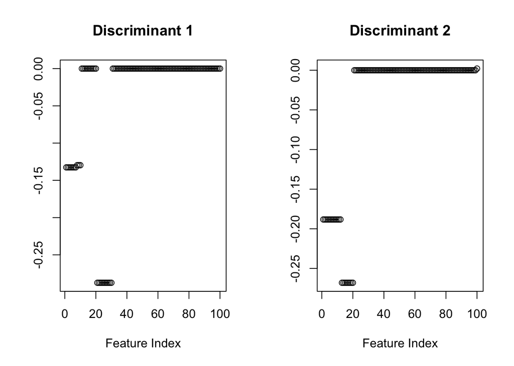

```r
plot(out)
```

```r
print(table(out$ypred[,out$K],yte))
```

```
##    yte
##      1  2  3  4
##   1 10  0  0  0
##   2  0 10  0  0
##   3  0  0 10  0
##   4  0  0  0 10
```